# Week 3 Peer Review - Data Science As A Field

Hung Nguyen

2023-04-10

## NYDC Shooting Incident Historic Data

### I) Data Import

I imported the shooting incident data from city of New York website data to a variable named ‘nyc’.

```r
library(tidyverse)
library(lubridate)
link_address = 'https://data.cityofnewyork.us/api/views/833y-fsy8/rows.csv?accessType=DOWNLOAD'
nyc = read_csv(link_address)
```

I removed these columns ‘INCIDENT_KEY’,‘X_COORD_CD’ ,‘Y_COORD_CD’,‘Latitude’,‘Longitude’,‘Lon_Lat’ from the imported data set. I can see OCCUR_DATE is in character so I fixed it into date object. I also added 2 more columns named INCIDENT_COUNT and MURDER(1 for fatal, 0 for non-fatal). Here is the summary of the data set after importing, removing unnecessary columns:

```r
nyc$Murder = as.integer(nyc$STATISTICAL_MURDER_FLAG)
nyc <- nyc %>%
  select(-c('INCIDENT_KEY','X_COORD_CD','Y_COORD_CD','Latitude','Longitude','Lon_Lat')) %>%
  mutate(OCCUR_DATE = mdy(OCCUR_DATE)) %>% mutate(INCIDENT_COUNT = 1)
summary(nyc)
```

```
##    OCCUR_DATE          OCCUR_TIME           BORO           LOC_OF_OCCUR_DESC
##  Min.   :2006-01-01   Length:27312      Length:27312       Length:27312
##  1st Qu.:2009-07-18   Class1:hms        Class :character   Class :character
##  Median :2013-04-29   Class2:difftime   Mode  :character   Mode  :character
##  Mean   :2014-01-06   Mode  :numeric
##  3rd Qu.:2018-10-15
##  Max.   :2022-12-31
##
##     PRECINCT      JURISDICTION_CODE LOC_CLASSFCTN_DESC LOCATION_DESC
##  Min.   :  1.00   Min.   :0.0000    Length:27312       Length:27312
##  1st Qu.: 44.00   1st Qu.:0.0000    Class :character   Class :character
##  Median : 68.00   Median :0.0000    Mode  :character   Mode  :character
##  Mean   : 65.64   Mean   :0.3269
##  3rd Qu.: 81.00   3rd Qu.:0.0000
##  Max.   :123.00   Max.   :2.0000
##                   NA's   :2
##  STATISTICAL_MURDER_FLAG PERP_AGE_GROUP       PERP_SEX
##  Mode :logical           Length:27312       Length:27312
##  FALSE:22046             Class :character   Class :character
##  TRUE :5266              Mode  :character   Mode  :character
##
##
##
##
##   PERP_RACE         VIC_AGE_GROUP        VIC_SEX            VIC_RACE
##  Length:27312       Length:27312       Length:27312       Length:27312
##  Class :character   Class :character   Class :character   Class :character
##  Mode  :character   Mode  :character   Mode  :character   Mode  :character
##
##
##
##
##      Murder       INCIDENT_COUNT
##  Min.   :0.0000   Min.   :1
##  1st Qu.:0.0000   1st Qu.:1
##  Median :0.0000   Median :1
##  Mean   :0.1928   Mean   :1
##  3rd Qu.:0.0000   3rd Qu.:1
##  Max.   :1.0000   Max.   :1
##
```

```r
nyc
```

```
## # A tibble: 27,312 × 17
##    OCCUR_DATE OCCUR_TIME BORO    LOC_O…¹ PRECI…² JURIS…³ LOC_C…⁴ LOCAT…⁵ STATI…⁶
##    <date>     <time>     <chr>   <chr>     <dbl>   <dbl> <chr>   <chr>   <lgl>
##  1 2021-05-27 21:30      QUEENS  <NA>        105       0 <NA>    <NA>    FALSE
##  2 2014-06-27 17:40      BRONX   <NA>         40       0 <NA>    <NA>    FALSE
##  3 2015-11-21 03:56      QUEENS  <NA>        108       0 <NA>    <NA>    TRUE
##  4 2015-10-09 18:30      BRONX   <NA>         44       0 <NA>    <NA>    FALSE
##  5 2009-02-19 22:58      BRONX   <NA>         47       0 <NA>    <NA>    TRUE
##  6 2020-10-21 21:36      BROOKL… <NA>         81       0 <NA>    <NA>    TRUE
##  7 2012-06-17 22:47      QUEENS  <NA>        114       0 <NA>    <NA>    FALSE
##  8 2010-03-08 19:41      BROOKL… <NA>         81       0 <NA>    <NA>    TRUE
##  9 2012-02-05 05:45      QUEENS  <NA>        105       0 <NA>    <NA>    FALSE
## 10 2012-08-26 01:10      QUEENS  <NA>        101       0 <NA>    MULTI … FALSE
## # … with 27,302 more rows, 8 more variables: PERP_AGE_GROUP <chr>,
## #   PERP_SEX <chr>, PERP_RACE <chr>, VIC_AGE_GROUP <chr>, VIC_SEX <chr>,
## #   VIC_RACE <chr>, Murder <int>, INCIDENT_COUNT <dbl>, and abbreviated
## #   variable names ¹LOC_OF_OCCUR_DESC, ²PRECINCT, ³JURISDICTION_CODE,
## #   ⁴LOC_CLASSFCTN_DESC, ⁵LOCATION_DESC, ⁶STATISTICAL_MURDER_FLAG
```

I’m going to look at relationship between gender,race, as well as the relationship between number of incidents versus the number of deaths.

### II) Data Analysis

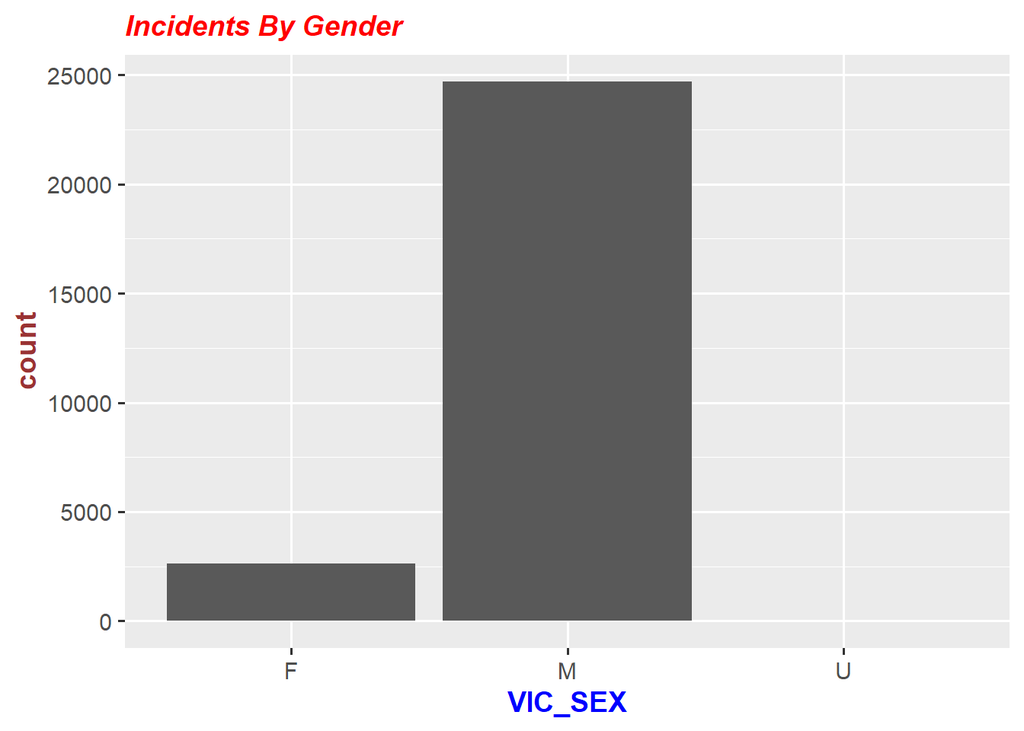

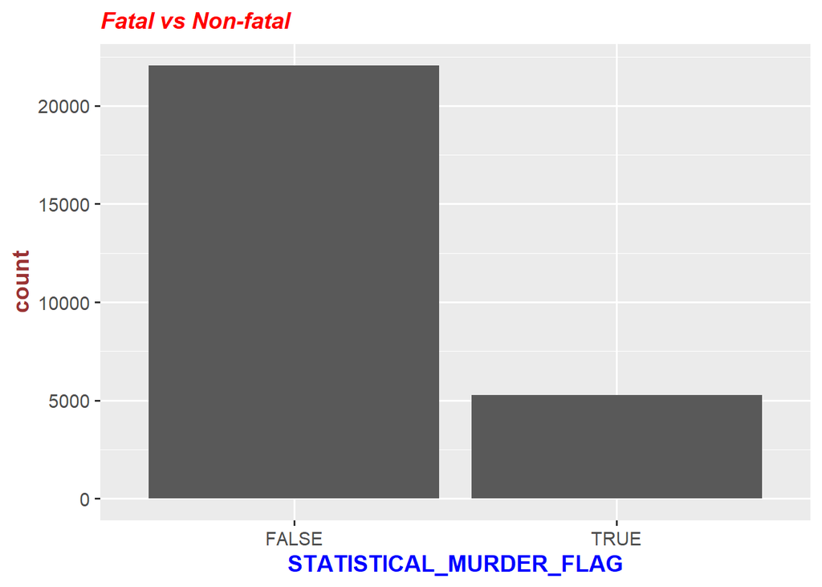

Here is the plot of non-fatal incidents count vs fatal incidents count. This count is taken from the column STATISTICAL_MURDER_FLAG where ‘FALSE’ = non-fatal and ‘TRUE’ = fatal. We can see the number of non-fatal incidents are roughly 4 times of fatal incidents.

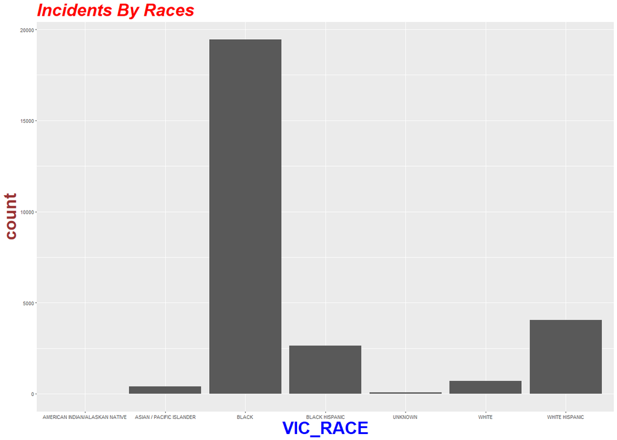

Above is the plot of each race group count. This is taken from column VIC_RACE. We can see BLACK race is the majored gender which has the most number of victims. Hence, together with gender, we can see that Black Male are the biggest victims.

This will further raise a couple of questions about our data. For example, we can look at age ranges of shooting victims, especially the black male victims. And we can also find out number of victims, age groups and genders of those victims by neighborhood.

I created a new variable called nyc_by_boro. I grouped the incidents by BORO, summed all the incidents count and murders count.

```r
nyc_by_boro = nyc %>%
  group_by(BORO) %>%
  summarize(INCIDENTS = sum(INCIDENT_COUNT), DEATHS = sum(Murder)) %>%
  ungroup()
nyc_by_boro
```

```
## # A tibble: 5 × 3
##   BORO          INCIDENTS DEATHS
##   <chr>             <dbl>  <int>
## 1 BRONX              7937   1542
## 2 BROOKLYN          10933   2122
## 3 MANHATTAN          3572    630
## 4 QUEENS             4094    810
## 5 STATEN ISLAND       776    162
```

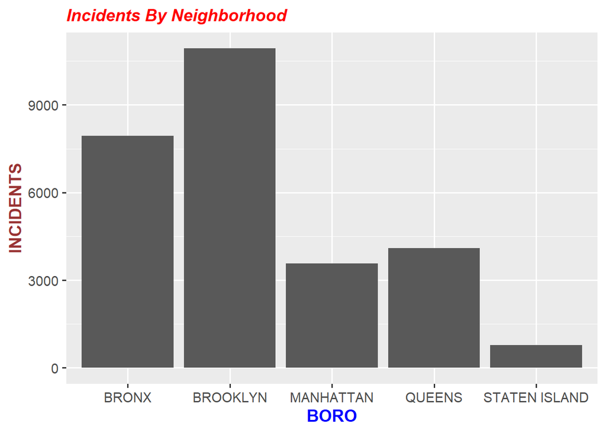

This is the plot of number of incidents happened in each neighborhood of New York City. We can see that Brooklyn has the highest number of incidents.

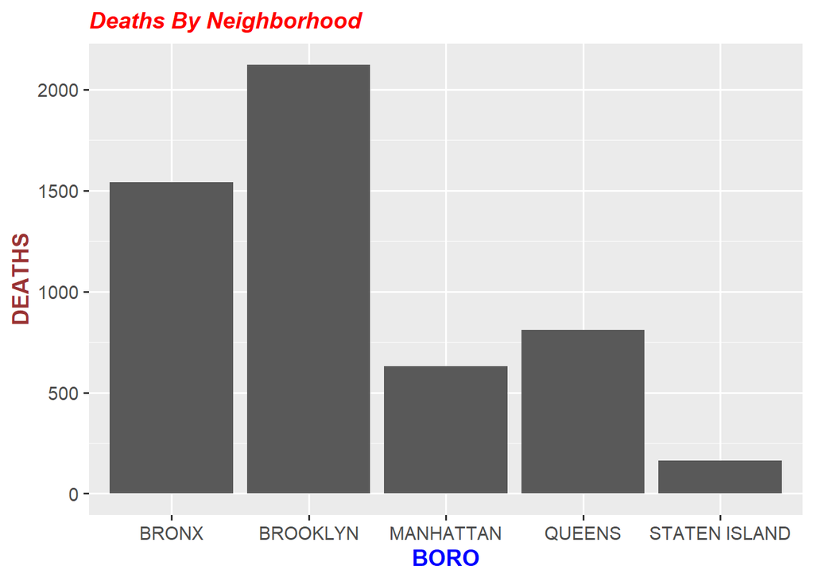

The above is the plot of number of deaths happened in each neighborhood of NYC given the shooting incidents there. We can see that Brooklyn also has the highest number of deaths.

Let’s create a variable called nyc_by_age. This variable is derived from nyc, grouped by VIC_AGE_GROUP, BORO and VIC_RACE. I also calculate INCIDENTS and DEATHS as before.

```r
nyc_by_age = nyc %>%
  group_by(VIC_AGE_GROUP, BORO, VIC_RACE) %>%
  summarize(INCIDENTS = sum(INCIDENT_COUNT), DEATHS = sum(Murder)) %>%
  ungroup()
nyc_by_age
```

```
## # A tibble: 159 × 5
##    VIC_AGE_GROUP BORO     VIC_RACE                       INCIDENTS DEATHS
##    <chr>         <chr>    <chr>                              <dbl>  <int>
##  1 <18           BRONX    AMERICAN INDIAN/ALASKAN NATIVE         2      0
##  2 <18           BRONX    ASIAN / PACIFIC ISLANDER               2      1
##  3 <18           BRONX    BLACK                                546     72
##  4 <18           BRONX    BLACK HISPANIC                       160     14
##  5 <18           BRONX    UNKNOWN                                1      0
##  6 <18           BRONX    WHITE                                  4      0
##  7 <18           BRONX    WHITE HISPANIC                       210     34
##  8 <18           BROOKLYN ASIAN / PACIFIC ISLANDER               4      0
##  9 <18           BROOKLYN BLACK                                975    128
## 10 <18           BROOKLYN BLACK HISPANIC                        54      8
## # … with 149 more rows
```

```
## # A tibble: 7 × 2
##   VIC_AGE_GROUP INCIDENTS
##   <chr>             <dbl>
## 1 <18                2839
## 2 1022                  1
## 3 18-24             10086
## 4 25-44             12281
## 5 45-64              1863
## 6 65+                 181
## 7 UNKNOWN              61
```

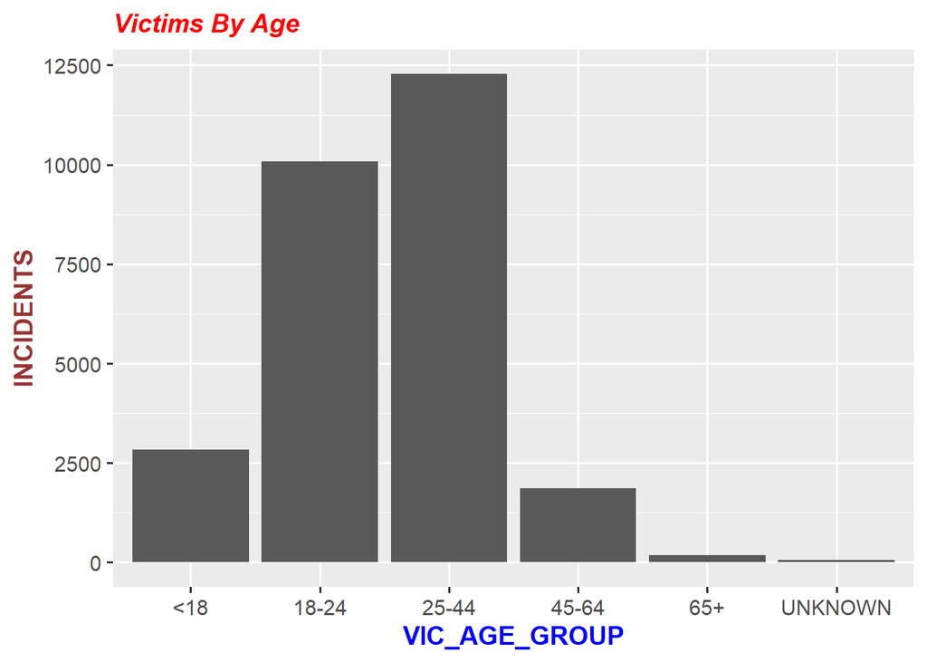

The plot of age group of victims versus number of incidents shows that age group 25-44 has the highest number of incidents, followed by age group 18-24.

Now let’s create another variable called nyc_by_age_brooklyn. I filtered data from Brooklyn neighborhood from nyc_by_age. Then I calculate the incidents percentage for each victim race in each age group. After generating the list, I can see that for each age_group, BLACK race has the highest percentage among most of groups.

```r
nyc_by_age_brooklyn = nyc_by_age %>% filter(BORO == 'BROOKLYN')
nyc_by_age_brooklyn = nyc_by_age_brooklyn %>%
  group_by(VIC_AGE_GROUP) %>%
  summarize(VIC_RACE = VIC_RACE, INCIDENT_PERCENTAGE = INCIDENTS*100/sum(INCIDENTS)) %>%
  ungroup()
nyc_by_age_brooklyn = nyc_by_age_brooklyn %>% filter(VIC_RACE == 'BLACK')
nyc_by_age_brooklyn
```

```
## # A tibble: 6 × 3
##   VIC_AGE_GROUP VIC_RACE INCIDENT_PERCENTAGE
##   <chr>         <chr>                  <dbl>
## 1 <18           BLACK                   87.5
## 2 18-24         BLACK                   84.9
## 3 25-44         BLACK                   82.6
## 4 45-64         BLACK                   75.4
## 5 65+           BLACK                   58.1
## 6 UNKNOWN       BLACK                   37.0
```

### III) MODEL ANALYSIS

I created a new variable called nyc_by_date. I grouped the incidents by OCCUR_DATE, summed all the incidents count and murders count for each given date. I also created a new column YEAR based on the year of the OCCUR_DATE

```r
nyc_by_date = nyc %>% group_by(OCCUR_DATE) %>%
  summarize(INCIDENTS = sum(INCIDENT_COUNT), DEATHS = sum(Murder)) %>%
  mutate(YEAR = year(OCCUR_DATE)) %>% ungroup()
nyc_by_date
```

```
## # A tibble: 5,761 × 4
##    OCCUR_DATE INCIDENTS DEATHS  YEAR
##    <date>         <dbl>  <int> <dbl>
##  1 2006-01-01         8      4  2006
##  2 2006-01-02         4      1  2006
##  3 2006-01-03         4      1  2006
##  4 2006-01-04         4      0  2006
##  5 2006-01-05         4      0  2006
##  6 2006-01-06         4      0  2006
##  7 2006-01-07         2      1  2006
##  8 2006-01-08         4      1  2006
##  9 2006-01-09         9      5  2006
## 10 2006-01-10         5      0  2006
## # … with 5,751 more rows
```

Let’s create a new variable called nyc_by_year. This variable is derived from nyc_by_date where INCIDENTS and DEATHS are grouped and summed for every given year.

```r
nyc_by_year = nyc_by_date %>%
  group_by(YEAR) %>%
  summarize(INCIDENTS = sum(INCIDENTS), DEATHS = sum(DEATHS)) %>%
  ungroup()
nyc_by_year
```

```
## # A tibble: 17 × 3
##     YEAR INCIDENTS DEATHS
##    <dbl>     <dbl>  <int>
##  1  2006      2055    445
##  2  2007      1887    373
##  3  2008      1959    362
##  4  2009      1828    348
##  5  2010      1912    405
##  6  2011      1939    373
##  7  2012      1717    288
##  8  2013      1339    223
##  9  2014      1464    249
## 10  2015      1434    283
## 11  2016      1208    223
## 12  2017       970    174
## 13  2018       958    204
## 14  2019       967    184
## 15  2020      1948    366
## 16  2021      2011    428
## 17  2022      1716    338
```

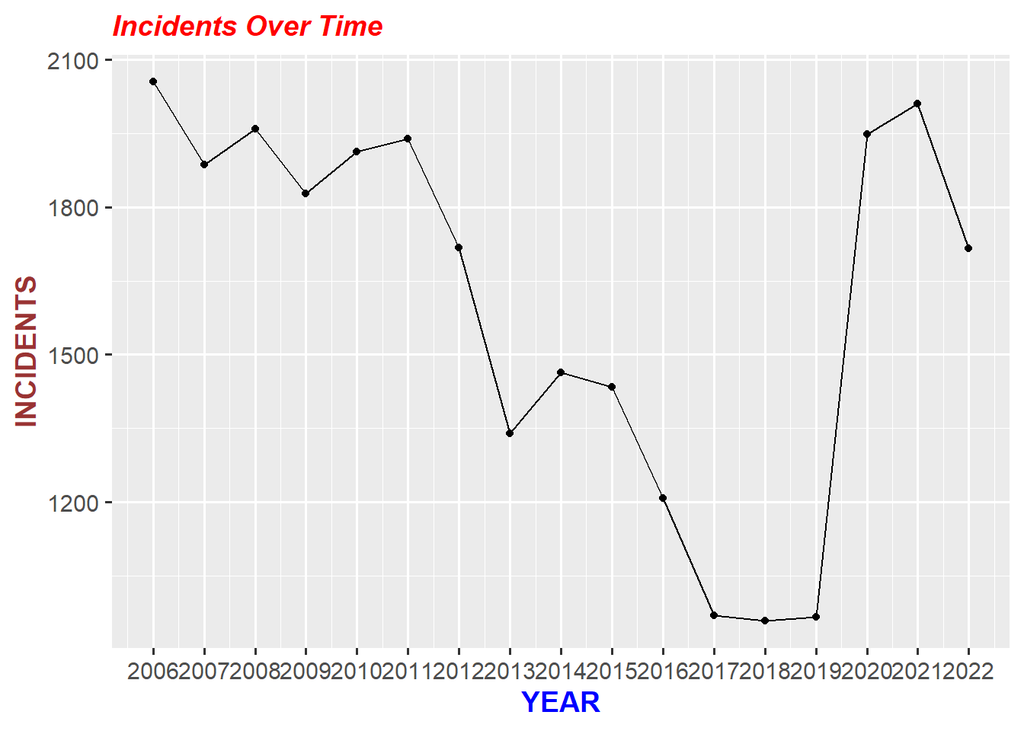

This is the plot of INCIDENTS vs YEAR. WE can see that the number of incidents decreased from 2006 to 2018 but started to increase back to the previous level since 2019.

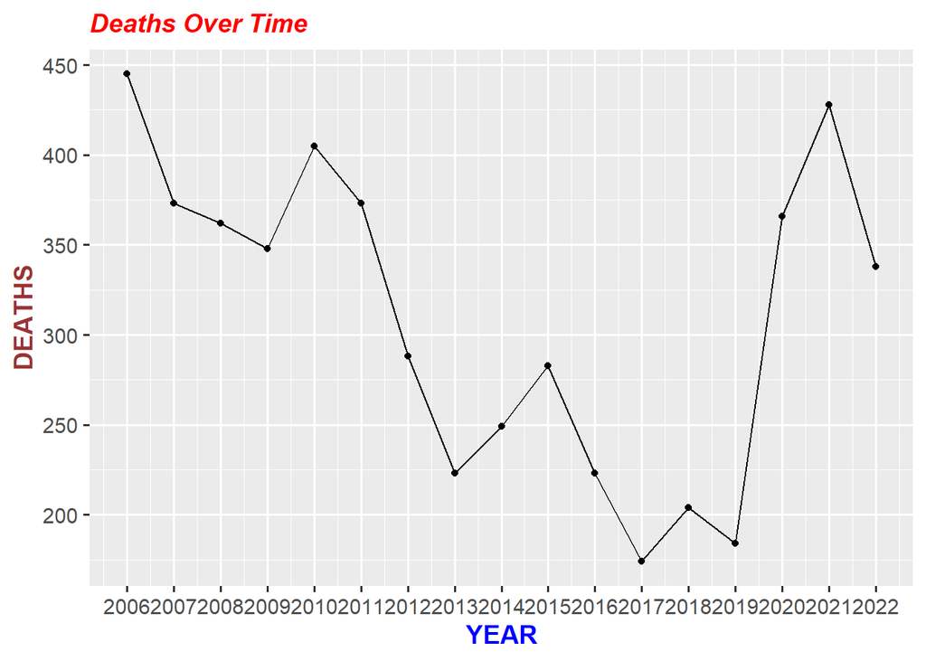

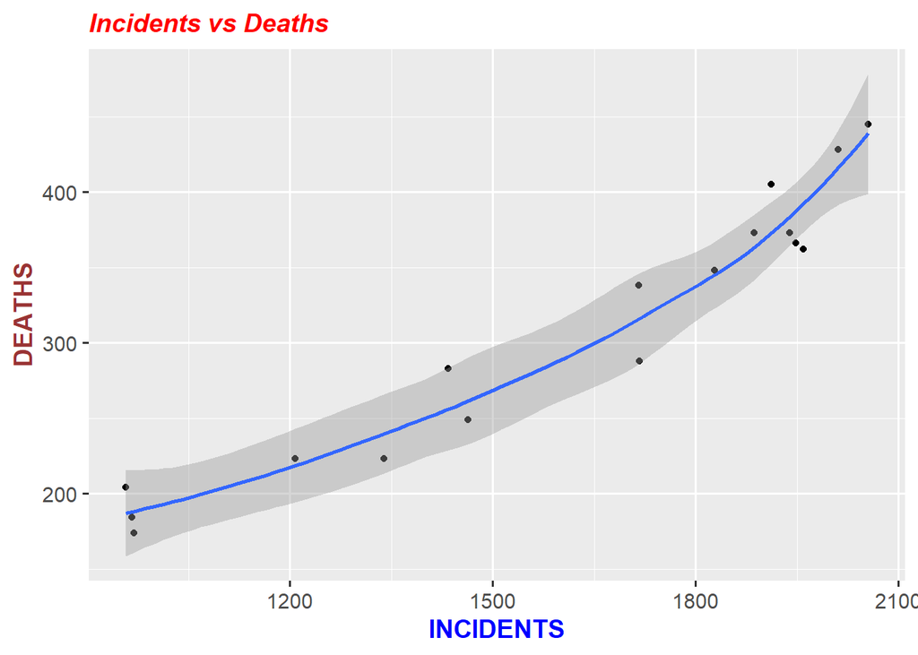

Above is the plot of INCIDENTS vs DEATHS. We may see a linear relationship between DEATHS and INCIDENTS.

So I’m going to implement a linear model for the relationship between DEATHS and INCIDENTS.

```r
model = lm(DEATHS ~ INCIDENTS, data = nyc_by_year)
summary(model)
```

```
##
## Call:
## lm(formula = DEATHS ~ INCIDENTS, data = nyc_by_year)
##
## Residuals:
##     Min      1Q  Median      3Q     Max
## -45.376 -16.774   0.367  11.009  39.344
##
## Coefficients:
##              Estimate Std. Error t value Pr(>|t|)
## (Intercept) -33.79833   26.55391  -1.273    0.222
## INCIDENTS     0.21385    0.01608  13.298 1.05e-09 ***
## ---
## Signif. codes:  0 '***' 0.001 '**' 0.01 '*' 0.05 '.' 0.1 ' ' 1
##
## Residual standard error: 25.31 on 15 degrees of freedom
## Multiple R-squared:  0.9218, Adjusted R-squared:  0.9166
## F-statistic: 176.8 on 1 and 15 DF,  p-value: 1.049e-09
```

This model seems to be a good fit since the coefficient for INCIDENTS is statically significant.

### IV) Conclusion & Bias

This analysis took information provided by the New York Police Department regarding shooting incidents and created a better understanding of the demographics of the incidents’ victims. The data shows that most incidents are non-fatal and majority of victims are black males. We can further investigate by looking at age groups, number of incidents by neighborhood. Moreover, we can also look at incidents number over period of time change. This may provide us an insight of the incident shooting trend in NYC over time.

As we look into more details, we can see a linear relationship between the number of incidents and number of fatal ones. It it a positive linear relationship which has statically significant coefficient.

There are a few possible source of bias:

- The data does not suggest whether or not the victim is a resident of NYC or just a visitor.
- Some incidents are not reported such as non-fatal incidents.
- The data was collected by NYPD but we do not know how these information was collected. It could affect the gender, race and age of victims.